# Analysis of Variability Sources: Batch and Elapsed Time

Tecla Duran Fort 2025-06-18

**Load Peak Table**

```r
df <- read.csv("../../data/peak_table_pool.csv")
df <- df %>% rename(SampleID = 1)
```

# 1. Compute Time Variables

## 1.1. Extract Datetime from SampleID

```r
df$datetime <- as.POSIXct(substr(df$SampleID, 1, 13), format = "%y%m%d_%H%M%S")
head(df[, c("SampleID", "datetime")])
```

```
##        SampleID            datetime
## 1 240319_132915 2024-03-19 13:29:15
## 2 240319_144050 2024-03-19 14:40:50
## 3 240319_155225 2024-03-19 15:52:25
## 4 240319_170400 2024-03-19 17:04:00
## 5 240319_181535 2024-03-19 18:15:35
## 6 240319_192710 2024-03-19 19:27:10
```

## 1.2. Compute *Batch* and *Elapsed Time* Variables

```r
df$batch <- rep(1:9, each = 15)
df <- df %>%
  group_by(batch) %>%
  mutate(
    elapsed_time = as.numeric(difftime(datetime, min(datetime), units = "secs")) / 3600
  ) %>%
  ungroup()

head(df[, c("SampleID", "datetime", "batch", "elapsed_time")])
```

```
## # A tibble: 6 × 4
##   SampleID      datetime            batch elapsed_time
##   <chr>         <dttm>              <int>        <dbl>
## 1 240319_132915 2024-03-19 13:29:15     1         0
## 2 240319_144050 2024-03-19 14:40:50     1         1.19
## 3 240319_155225 2024-03-19 15:52:25     1         2.39
## 4 240319_170400 2024-03-19 17:04:00     1         3.58
## 5 240319_181535 2024-03-19 18:15:35     1         4.77
## 6 240319_192710 2024-03-19 19:27:10     1         5.97
```

# 2. Association with Elapsed Time and Batch

## 2.1. Technical Variability in GC-IMS Data

In GC-IMS data analysis, technical factors such as **instrumental drift** and **batch effects** can significantly impact the reproducibility of measurements. These effects can arise from variations in **environmental conditions** (e.g., temperature, pressure) and **instrumental tolerances** (e.g., column aging, contamination). Such variability can introduce noise and misalign data, making it crucial to assess how these factors influence the stability of the clusters in the dataset (Rodríguez-Pérez et al., 2018; Fernández et al., 2019).

## 2.2. Methodology

We evaluate the influence of **elapsed time** (the time between the start of the batch and the analysis of a given sample) and the **batch number** (grouping of samples analyzed together) on the **intensity of the clusters**.

### Elapsed Time

Due to the way the study was conducted, **elapsed time** is indirectly related to the time a sample remained at ambient temperature before analysis, as samples were initially stored frozen. This variable reflects the potential degradation or changes in sample composition due to temperature exposure over time.

### Batch Number

**Batch number** encodes both the measurement day and the grouping of samples processed together. This captures: - Possible differences in instrumental conditions between days, - The number of measurement cycles (i.e., how many times the instrument was restarted or calibrated), - The time elapsed since sample collection, as all samples were originally collected simultaneously but processed in separate batches.

Together, these variables represent **temporal and procedural sources of variability** that may influence the measured signal intensities.

### Quantifying Explained Variance with $R^2$

To evaluate the extent to which each variable explains the variation in cluster intensity, we compute the **coefficient of determination** $R^2$ for each column (i.e., the intensity of each cluster across samples) separately, using two independent linear models: - One with **elapsed time** as the predictor, - One with **batch number** as the predictor.

The $R^2$ value is defined as:

$$R^2 = 1 - \frac{SS_{\text{res}}}{SS_{\text{tot}}}$$

where: - $SS_{\text{tot}} = \sum_{i=1}^{n} (y_i - \bar{y})^2$ is the total sum of squares, representing the overall variance in the observed values. - $SS_{\text{res}} = \sum_{i=1}^{n} (y_i - \hat{y}_i)^2$ is the residual sum of squares, quantifying the part of the variance not explained by the model.

Since both quantities are expressed in the same units, the ratio $SS_{\text{res}} / SS_{\text{tot}}$ represents the proportion of unexplained variance. Subtracting this from 1 yields the proportion of variance explained by the model. Therefore, the $R^2$ value indicates how much of the variability in cluster intensity is attributable to the explanatory variable.

$$R^2 = \frac{\text{Explained Variance}}{\text{Total Variance}}$$

### Independence of Elapsed Time and Batch Number

To confirm that the two explanatory variables are statistically independent, we compute the **Pearson correlation coefficient** between **elapsed time** and **batch number**:

```r
cor(df$elapsed_time, df$batch, method = "pearson")
```

```
## [1] 0.0144859
```

The result ($r = 0.01$) indicates negligible linear correlation, justifying the separate analysis of these two factors.

### Analysis Procedure

1. **Model fitting and R² computation**:
   - For each cluster, two univariate linear models are fitted:
     - One with **elapsed time** as the predictor,
     - One with **batch number** as the predictor.
   - The corresponding $R^2$ values indicate the proportion of variance in cluster intensity explained by each variable.
2. **Estimation of residual variance**:
   - The remaining variance is approximated as:
     $$1 - (R^2_{\text{elapsed time}} + R^2_{\text{batch number}})$$
   - This residual variance captures the portion of variability not explained by the modeled variables, which may include instrumental noise, uncontrolled experimental factors, or latent sources of variability.

## 2.3. Visualization of Explained Variance

We present the results in a stacked bar chart, where each cluster is represented by a bar. The different sections of each bar correspond to the proportion of variance explained by **elapsed time**, **batch number**, and **other factors**.

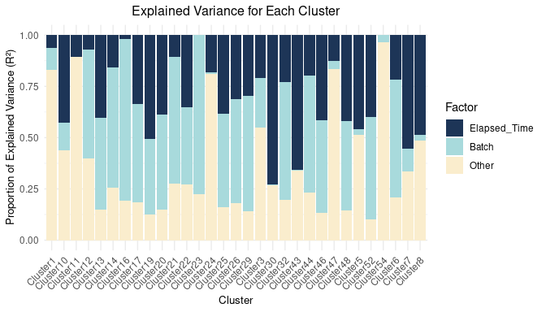

### Overall Contribution of Each Factor

To evaluate the overall contribution of each factor, we compute the **mean $R^2$** across all clusters. Since each $R^2$ value represents the proportion of variance explained in one cluster, taking the average is equivalent to **summing the explained variance across all clusters and dividing by the total variance**. In other words, the mean $R^2$ reflects the **overall fraction of variance in the dataset** that can be attributed to each factor.

This approach gives a clear and interpretable summary of how much signal variability is explained by **elapsed time**, **batch number**, and **other factors** when considering the dataset as a whole.

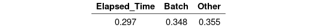

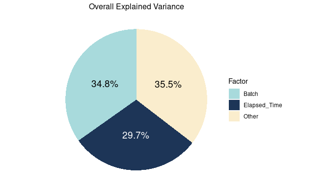

Overall variance explained by elapsed time, batch number, and residual sources

## 2.4. Conclusion

Based on the mean R² values, we can draw the following conclusions:

1. **Elapsed Time** explains approximately **29.7%** of the variance in the intensities.
2. **Batch Number** accounts for **34.8%** of the variance,
3. The remaining **35.5%** of the variance is attributed to **Other factors**, which might include environmental influences, instrumental factors, or unmeasured variables.

If we were to remove the influence of Elapsed Time and Batch Number, we would remove a combined 64.5% of the variance in the data. Since these two factors are not correlated between them, their effects are additive, meaning the total explained variance by Elapsed Time and Batch Number is the sum of their individual contributions.

# 3. Principal Component Analysis

We will use Principal Component Analysis (PCA) as an **exploratory tool** to assess how **elapsed time** and **batch number** influence the intensity variations of the clusters.

We will plot the first two principal components (PC1 and PC2), which capture the most significant variance in the data. If we observe clear patterns or separations in the plots, it suggests that these factors are influencing the measurements.

Additionally, we will evaluate the explained variance by the first few components to understand how much of the overall variability in the data is captured by each component.

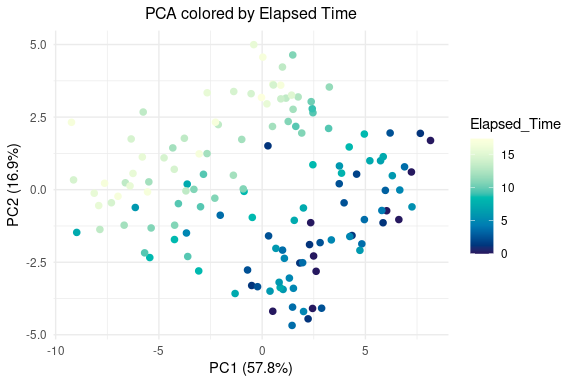

PCA plot of cluster intensities colored by elapsed time

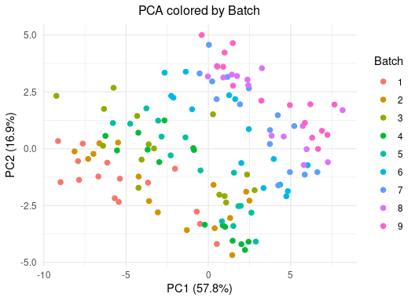

PCA plot of cluster intensities colored by batch number

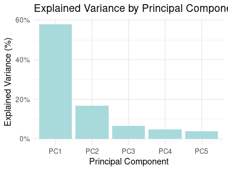

Percentage of total variance explained by the first five principal components

**Interpretation**

The PCA plots reveal how **elapsed time** and **batch number** impact the data variability. The explained variance plot shows how much of the total variance is explained by the first components.

# 4. References

- Rodríguez-Pérez, R., Cortés, R., Guamán, A., Pardo, A., Torralba, Y., Gómez, F., Roca, J., Barberà, J. A., Cascante, M., & Marco, S. (2018). *Instrumental drift removal in GC-MS data for breath analysis: the short-term and long-term temporal validation of putative biomarkers for COPD*. Journal of Breath Research, 12(3), 036007. https://doi.org/10.1088/1752-7163/aaa492
- Fernandez, L., Blanco, A., Mallafré-Muro, C., & Marco, S. (n.d.). *Towards batch correction for GC-IMS data*. Department of Electronic and Biomedical Engineering, University of Barcelona; The Institute for Bioengineering of Catalonia.